# Main Notebook

ITESO

Microstructure and Trading systems

Diego Pintor Ochoa, if726622@iteso.mx

June 2022 | Repository: [Link](https://github.com/PintorOD1997/Lab1-Market-Microstructure-)

Laboratory 1  
Market Microstructure

Abstract

This Laboratory was created with the purpose of demonstrating the basic metrics of the OrderBooks and Public Trades, providing quantitative insights on them, and highlighting the main concepts that will be used throughout the course.

# 1. Introduction

Market microstructure is a branch of finance concerned with the details of how exchange occurs in markets. While the theory of market microstructure applies to the exchange of real or financial assets, more evidence is available on the microstructure of financial markets due to the availability of transactions data from them.

The major thrust of market microstructure research examines the ways in which the working processes of a market affect determinants of transaction costs, prices, quotes, volume, and trading behavior. In the twenty-first century, innovations have allowed an expansion into the study of the impact of market microstructure on the incidence of market abuse, such as insider trading, market manipulation and broker-client conflict.

# 2. Install/Load Packages and Depedencies

## 2.1 Python Packages

In order to run this notebook, it is necessary to have installed and/or have the *requirements.txt* file with the following:

- pandas>=1.4.2
- numpy>=1.18.5
- jupyter>=1.0.0
- plotly>=4.14

## 2.2 Files Dependencies

The following are the file dependencies that are needed to run this notebook:

- files/orderbooks_05jul21.json : Orderbook in JSON format
- files/btcusdt_binance.csv : Public Trades in CSV format

## 2.3 Install Packages

```python
%%capture
#!{sys.executable} -m pip install -r requirements.txt
# Install all the pip packages in the requirements.txt
import numpy as np
import pandas as pd
import data as dt
import functions
```

# 3. Data Description

```python
# Load Data
OB = dt.openOB()
PT = dt.openPT()
```

```python
OBmetrics,m1,m4= functions.OB_metrics(OB)
OBohlcv = functions.OB_OHLCV(OBmetrics)
OBIMBmoments = functions.OBIMB_Moments(OBmetrics)
tradesHora, volume, count, OHLCV = functions.PT_metrics(PT)
```

# 4.1. OrderBook Basic Metrics

```python
OBmetrics
```

|  | Spread | Mid Price | Bid Volume | Ask Volume | Total Volume | OrderBook Imbalance | Weighted MidPrice (Ask) | Weighted MidPrice (Bid) | VWAP | Bids ToB | Asks ToB |
| --- | --- | --- | --- | --- | --- | --- | --- | --- | --- | --- | --- |
| 2021-07-05 13:06:46.571000+00:00 | 5.0 | 28272.5 | 32.100178 | 31.699457 | 63.799634 | 0.503140 | 14225.039010 | 28272.515925 | 28272.484298 | 28270.0 | 28275.0 |
| 2021-07-05 13:06:47.918000+00:00 | 5.0 | 28272.5 | 32.100178 | 31.699457 | 63.799634 | 0.503140 | 14225.039010 | 28272.515925 | 28272.484298 | 28270.0 | 28275.0 |
| 2021-07-05 13:06:49.414000+00:00 | 5.0 | 28272.5 | 32.100178 | 31.699457 | 63.799634 | 0.503140 | 14225.039010 | 28272.515925 | 28272.484298 | 28270.0 | 28275.0 |
| 2021-07-05 13:06:51.077000+00:00 | 3.0 | 28276.5 | 36.263315 | 36.929183 | 73.192497 | 0.495451 | 14009.627607 | 28276.486545 | 28276.513646 | 28275.0 | 28278.0 |
| 2021-07-05 13:06:52.426000+00:00 | 3.0 | 28276.5 | 36.263315 | 36.929183 | 73.192497 | 0.495451 | 14009.627607 | 28276.486545 | 28276.513646 | 28275.0 | 28278.0 |
| ... | ... | ... | ... | ... | ... | ... | ... | ... | ... | ... | ... |
| 2021-07-05 14:06:40.583000+00:00 | 7.0 | 28358.5 | 19.984121 | 23.940057 | 43.924178 | 0.454969 | 12902.226545 | 28358.184780 | 28358.815220 | 28355.0 | 28362.0 |
| 2021-07-05 14:06:41.919000+00:00 | 7.0 | 28358.5 | 19.984121 | 23.940057 | 43.924178 | 0.454969 | 12902.226545 | 28358.184780 | 28358.815220 | 28355.0 | 28362.0 |
| 2021-07-05 14:06:43.416000+00:00 | 7.0 | 28358.5 | 19.984121 | 23.940057 | 43.924178 | 0.454969 | 12902.226545 | 28358.184780 | 28358.815220 | 28355.0 | 28362.0 |
| 2021-07-05 14:06:45.070000+00:00 | 5.0 | 28356.5 | 18.140884 | 22.614192 | 40.755075 | 0.445120 | 12622.034854 | 28356.225908 | 28356.774402 | 28354.0 | 28359.0 |
| 2021-07-05 14:06:46.412000+00:00 | 5.0 | 28356.5 | 18.140884 | 22.614192 | 40.755075 | 0.445120 | 12622.034854 | 28356.225908 | 28356.774402 | 28354.0 | 28359.0 |

2401 rows × 11 columns

### Median of time between trades (m1) and Number of Price Levels in the OrderBook (m4)

```python
m1,m4[0]
```

```
(1500.0, 25)
```

# 4.2. OrderBook Open, High, Low, Close, Volume (OHLCV)

```python
OBohlcv
```

|  | Mid Price open | Mid Price high | Mid Price low | Mid Price close | Total Volume |
| --- | --- | --- | --- | --- | --- |
| 2021-07-05 13:06:30+00:00 | 28272.5 | 28282.5 | 28272.5 | 28282.5 | 583.699035 |
| 2021-07-05 13:07:00+00:00 | 28296.0 | 28302.0 | 28285.0 | 28285.0 | 1373.052492 |
| 2021-07-05 13:07:30+00:00 | 28287.5 | 28324.0 | 28287.5 | 28324.0 | 1234.500021 |
| 2021-07-05 13:08:00+00:00 | 28324.0 | 28324.0 | 28300.0 | 28304.0 | 1260.196650 |
| 2021-07-05 13:08:30+00:00 | 28305.5 | 28312.0 | 28305.5 | 28312.0 | 1373.692761 |
| ... | ... | ... | ... | ... | ... |
| 2021-07-05 14:04:30+00:00 | 28327.0 | 28346.0 | 28327.0 | 28346.0 | 894.831927 |
| 2021-07-05 14:05:00+00:00 | 28349.0 | 28349.0 | 28329.5 | 28340.0 | 859.527106 |
| 2021-07-05 14:05:30+00:00 | 28340.0 | 28359.5 | 28340.0 | 28358.0 | 718.759583 |
| 2021-07-05 14:06:00+00:00 | 28358.0 | 28364.5 | 28358.0 | 28364.5 | 842.897646 |
| 2021-07-05 14:06:30+00:00 | 28364.5 | 28364.5 | 28356.5 | 28356.5 | 455.790087 |

121 rows × 5 columns

# 4.3. OrderBook Imbalance Moments (Mean, Variance, Skewness, Kurtosis)

```python
OBIMBmoments
```

```
{'Mean': 0.3675593708841436,
 'Variance': 0.012447697761364186,
 'Skewness': 0.3924826521789637,
 'Kurtosis': 0.1960527433391892}
```

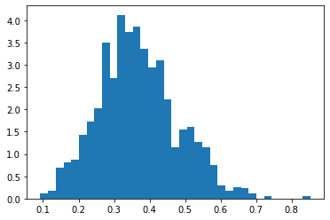

```python
import matplotlib.pyplot as plt
plt.hist(OBmetrics["OrderBook Imbalance"],bins="auto",density = True);
```

# 4.4. Public Trades Hourly Trades

```python
tradesHora.head()
```

```
timestamp
2022-05-10 00:00:00    12000
2022-05-10 01:00:00    11900
2022-05-10 02:00:00    11900
2022-05-10 03:00:00    11900
2022-05-10 04:00:00    12000
Freq: 60T, Name: side, dtype: int64
```

# 4.5. Sell and Buy Volume, Difference in Trade Count

```python
volume
```

```
side
buy      7338.91217
sell    10148.21080
Name: amount, dtype: float64
```

```python
count
```

```
1300
```

# 4.6 Public Trades OHLVC

```python
OHLCV.head()
```

| timestamp | price open | price high | price low | price close | amount |
| --- | --- | --- | --- | --- | --- |
| 2022-05-10 00:00:00 | 30075.19 | 30842.21 | 29758.78 | 30770.010 | 897.80374 |
| 2022-05-10 01:00:00 | 30722.91 | 31340.94 | 30702.40 | 30900.682 | 751.42903 |
| 2022-05-10 02:00:00 | 30883.21 | 31390.16 | 30797.60 | 31033.700 | 731.59613 |
| 2022-05-10 03:00:00 | 31045.10 | 31152.46 | 30640.13 | 30664.400 | 729.39643 |
| 2022-05-10 04:00:00 | 30682.08 | 31340.86 | 30602.80 | 31215.350 | 768.91706 |

# 5. Results

## 5.1 OrderBook Results

The *Weighted Mid Price (Ask)* was significantly lower than the *Weighted Mid Price (Bid)*, in fact, it was almost exactly half. This can be attributed to the calculation method of the *Weighted Mid Price (Ask)*, which uses only one source of prices.

The *VWAP* remained relatively close to the Mid Price the entire time, which means that, adjusted to volume, the average price remained really close to the settlements between Bids and Asks.

## 5.2 Public Trades Results

We can observe that, hour-by-hour, the amount of Public Trades remained roughly the same.

We can also observe, that despite the *volume* being heavily biased towards selling, the *Difference in Trade Count* remained on the side of *Buying*, 1300 trades on that side.

## 6. Final Conclusions

Market Microstructures provide a more in-depth analysis of the financial markets, on top of the traditional analysis already being made. This type of analysis includes a snapshot of the current trends observing the OrderBook, which provides us insight on how many Bids or Asks are being made, and this is chained with their prices to get a more complete snapshot of the market. Due to the sheer size of the market, the amount of transactions needs to be observed on the miliseconds order, which is both more precise and more intensive in resources.

A more structured set of instructions, provided for this Laboratory, would have been a welcome addition to this, but inspite of all the shortcomings, this Laboratory was a really interesting approach to the financial markets.

Due to the nature and size constraint of the origin files for the OrderBook and Public Trades, more extensive analysis of more difficult market conditions wasn't possible, due to such market conditions not being present in the records.

Due to time constraints, more in-depth visualization wasn't implemented, Parquet file type was possible, but not implemented, again, due to time constraints.

# 7. References

[1] O'Hara, Maureen, Market Microstructure Theory, Blackwell, Oxford, 1995, ISBN 1-55786-443-8, p.1.

[2] R.Almgren and N.Chriss, "Optimal execution of portfolio transactions" J. Risk, 3 (Winter 2000/2001) pp.5–39